# Probability and Statistics

# Lab Assignment 1: Naive Bayes Classifier

### *ANDRIEIEV KYRYL, HUMENIUK MYKHAILO, BILINSKYI ANDRII*

## Introduction

During the past three weeks, we learned a couple of essential notions and theorems, and one of the most important among them is the *Bayes theorem*.

One of its applications is **Naive Bayes classifier**, which is a probabilistic classifier whose aim is to determine which class some observation probably belongs to by using the Bayes formula:
$$\mathsf{P}(\mathrm{class}\mid
\mathrm{observation})=\frac{\mathsf{P}(\mathrm{observation}\mid\mathrm{class})\mathsf{P}(\mathrm{class})}{\mathsf{P}(\mathrm{observation})}$$

Under the strong independence assumption, one can calculate $\mathsf{P}(\mathrm{observation} \mid \mathrm{class})$ as
$$\mathsf{P}(\mathrm{observation}) =
\prod_{i=1}^{n} \mathsf{P}(\mathrm{feature}_i), \qquad
\mathsf{P}(\mathrm{observation} \mid \mathrm{class}) = \prod_{i=1}^{n}
\mathsf{P}(\mathrm{feature}_i \mid \mathrm{class}),$$
where $n$ is the total number of features describing a given observation. Thus, $\mathsf{P}(\mathrm{class}|\mathrm{observation})$ now can be calculated as

$$\mathsf{P}(\mathrm{class} \mid
\mathrm{\mathrm{observation}}) = \mathsf{P}(\mathrm{class})\times
\prod_{i=1}^{n}\frac{\mathsf{P}(\mathrm{feature}_i\mid
\mathrm{class})}{\mathsf{P}(\mathrm{feature}_i)}\tag{1}$$

## Data description

**0 - authors** This data set consists of citations of three famous writers: Edgar Alan Poe, Mary Wollstonecraft Shelley and HP Lovecraft. The task with this data set is to classify a piece of text with the author who was more likely to write it.

```r
# list of used libraries
library(tidytext)
library(readr)
library(dplyr)
```

```r
library(ggplot2)
library(caret)
```

### Data pre-processing

```r
list.files(getwd())
```

```
## [1] "data"
## [2] "intro-R.Rmd"
## [3] "Lab1_Naive_Bayes_Classifier_Templatee.html"
## [4] "Lab1_Naive_Bayes_Classifier_Templatee.Rmd"
## [5] "main.R"
## [6] "stop_words.txt"
```

```r
list.files("data/0-authors")
```

```
## [1] "test.csv"  "train.csv"
```

```r
# source paths
test_path <- "data/0-authors/test.csv"
train_path <- "data/0-authors/train.csv"
# get data frames from files
train <- read.csv(file = train_path, stringsAsFactors = FALSE)
test <- read.csv(file = test_path, stringsAsFactors = FALSE)
# get authors
authors <- unique(train %>% pull(author))
# get stop words
stop_words <- read_file("stop_words.txt")
splitted_stop_words <- strsplit(stop_words, split = '\n')
splitted_stop_words <- splitted_stop_words[[1]]
```

### Data visualization

```
## No summary function supplied, defaulting to `mean_se()`
```

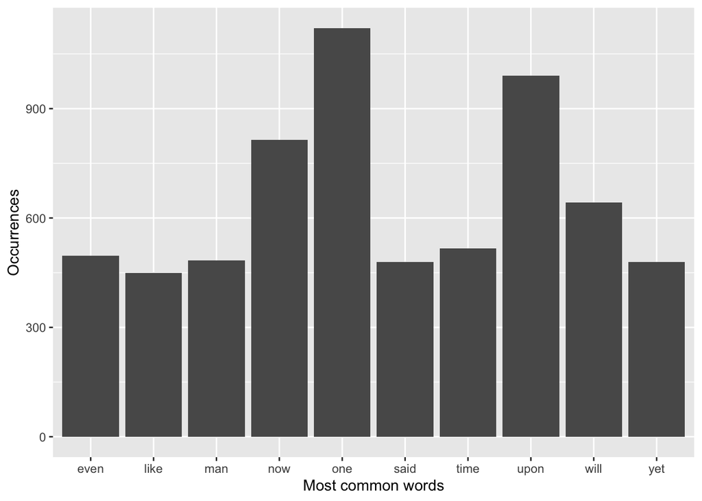

```r
text <- unnest_tokens(train, 'splitted', 'text', token="words") %>%
             filter(!splitted %in% splitted_stop_words)

total_words <- head(text %>% count(splitted, sort = TRUE), 10)
lovecraft <- head(text[text$author == "HP Lovecraft",] %>% count(splitted, sort = TRUE), 10)
alanpoe <- head(text[text$author == "Edgar Alan Poe",] %>% count(splitted, sort = TRUE), 10)
mary <- head(text[text$author == "Mary Wollstonecraft Shelley ",] %>% count(splitted, sort = TRUE), 10)
ggplot(total_words, aes(x = splitted, y = n)) +
  geom_bar(stat = "summary") +
  ylab("Occurrences") + xlab("Most common words")
```

```
## No summary function supplied, defaulting to `mean_se()`
```

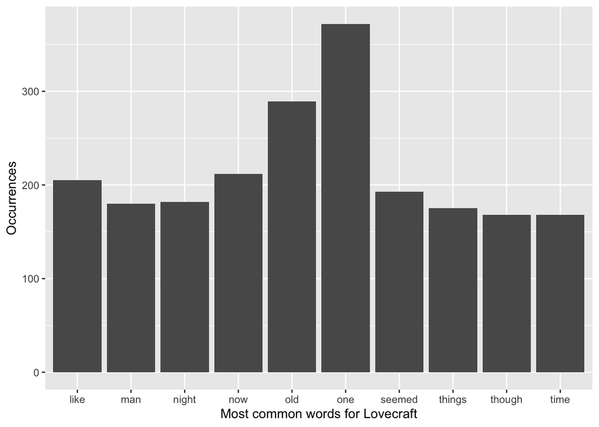

```r
ggplot(lovecraft, aes(x = splitted, y = n)) +
  geom_bar(stat = "summary") +
  ylab("Occurrences") + xlab("Most common words for Lovecraft")
```

```
## No summary function supplied, defaulting to `mean_se()`
```

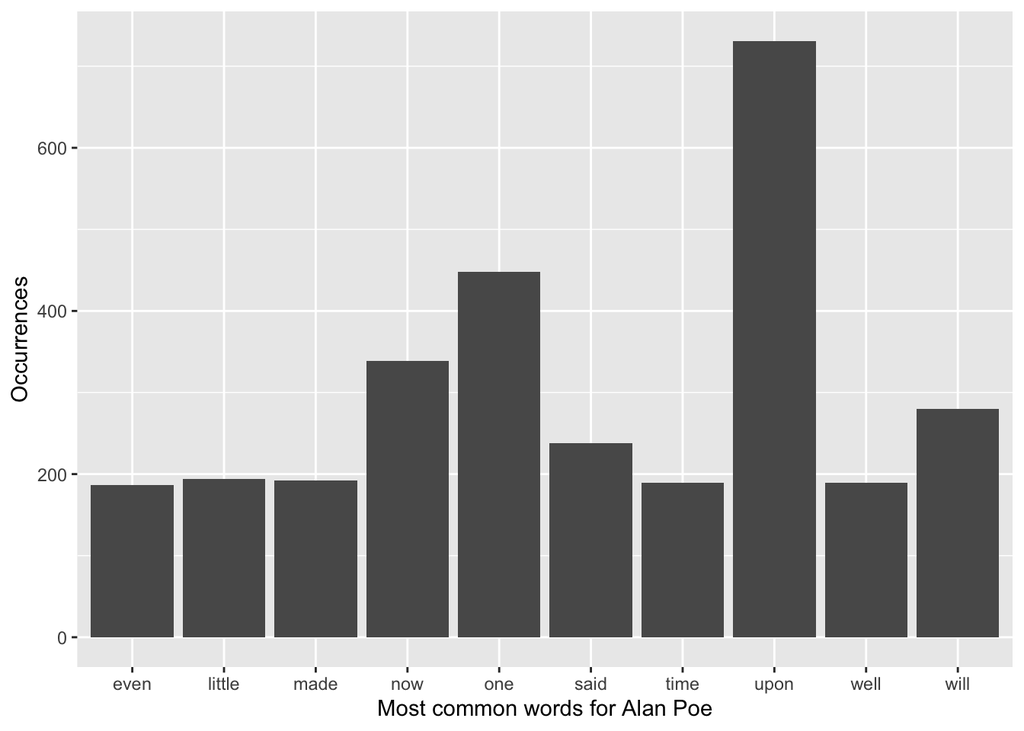

```r
ggplot(alanpoe, aes(x = splitted, y = n)) +
  geom_bar(stat = "summary") +
  ylab("Occurrences") + xlab("Most common words for Alan Poe")
```

```
## No summary function supplied, defaulting to `mean_se()`
```

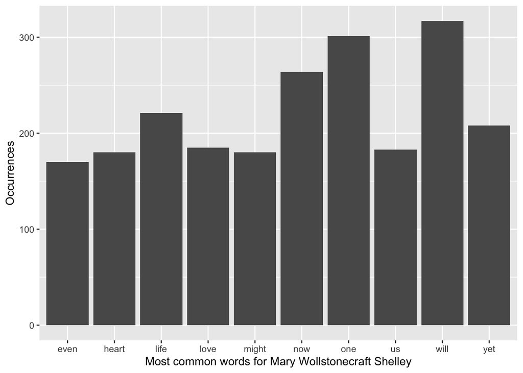

```r
ggplot(mary, aes(x = splitted, y = n)) +
  geom_bar(stat = "summary") +
  ylab("Occurrences") + xlab("Most common words for Mary Wollstonecraft Shelley")
```

## Classifier implementation

```r
author_probability <- data.frame(
  id = 1:3,
  author = authors,
  probability = c((nrow(train[train$author == authors[2],]) / nrow(train)),
                  (nrow(train[train$author == authors[1],]) / nrow(train)),
                  (nrow(train[train$author == authors[3],]) / nrow(train))),
  stringsAsFactors = FALSE
)
naiveBayes <- setRefClass("naiveBayes",
                          # data frame with probabilities of all authors
                          fields = list(data = "data.frame", labels = "vector", total_words_bag = "data.frame", lovecraft_bag = "data.frame", alanpoe_bag = "data.frame", mary_bag = "data.frame"),
                          methods = list(
                            is_integer0 = function(x)
                            {
                              if (length(x) == 0 & is.integer(x)) {
                                return(0)
                              } else {
                                return(x)
                              }
                            },
                            fit = function(X = data, Y = labels)
                            {
                              # split all citations into words without stop words
                              tidy_text <- unnest_tokens(X, 'word', 'text', token = "words") %>%
                                filter(!word %in% splitted_stop_words)
                              # get all bags of words
                              total_words_bag <<- tidy_text %>% count(word, sort = TRUE)
                              lovecraft_bag <<- tidy_text[tidy_text$author == Y[1],] %>% count(word, sort = TRUE)
                              alanpoe_bag <<- tidy_text[tidy_text$author == Y[2],] %>% count(word, sort = TRUE)
                              mary_bag <<- tidy_text[tidy_text$author == Y[3],] %>% count(word, sort = TRUE)
                            },
                            predict = function(message)
                            {
                              # process the message
                              message <- gsub('[[:punct:] ]+', ' ', message)
                              message <- casefold(message, upper = FALSE)
                              splitted_message <- strsplit(message, split = ' ')
                              splitted_message <- splitted_message[[1]]
                              splitted_message <- unlist(splitted_message)[!(unlist(splitted_message) %in% splitted_stop_words)]
                              lovecraft_prediction = author_probability[author_probability$author == authors[1], "probability"]
                              alanpoe_prediction = author_probability[author_probability$author == authors[2], "probability"]
                              mary_prediction = author_probability[author_probability$author == authors[3], "probability"]
                              for (i in splitted_message) {
                                lovecraft_prediction <- lovecraft_prediction * ((is_integer0(lovecraft_bag[lovecraft_bag$word == i, "n"]) + 1) / (nrow(lovecraft_bag) + nrow(total_words_bag)))
                                alanpoe_prediction <- alanpoe_prediction * ((is_integer0(alanpoe_bag[alanpoe_bag$word == i, "n"]) + 1) / (nrow(alanpoe_bag) + nrow(total_words_bag)))
                                mary_prediction <- mary_prediction * ((is_integer0(mary_bag[mary_bag$word == i, "n"]) + 1) / (nrow(mary_bag) + nrow(total_words_bag)))
                              }
                              most_likely <- max(c(lovecraft_prediction, alanpoe_prediction, mary_prediction))
                              if (most_likely == lovecraft_prediction) {
                                return("HP Lovecraft")
                              } else if (most_likely == alanpoe_prediction) {
                                return("Edgar Alan Poe")
                              } else {
                                return("Mary Wollstonecraft Shelley ")
                              }
                            },
                            score = function(test_data) {
                              test_data["prediction"] <- apply(test_data['text'], 1, FUN = model$predict)
                              cm <- confusionMatrix(factor(test_data$prediction), factor(test_data$author))
                              print(cm[["byClass"]][, "F1"])
                              return(cm)
                            }
                          )
)
```

## Measure effectiveness of your classifier

```r
model <- naiveBayes(data = train, labels = authors)
model$fit()
cm <- model$score(test)
```

```
##               Class: Edgar Alan Poe                 Class: HP Lovecraft
##                           0.8263224                           0.8121059
## Class: Mary Wollstonecraft Shelley
##                           0.8320085
```

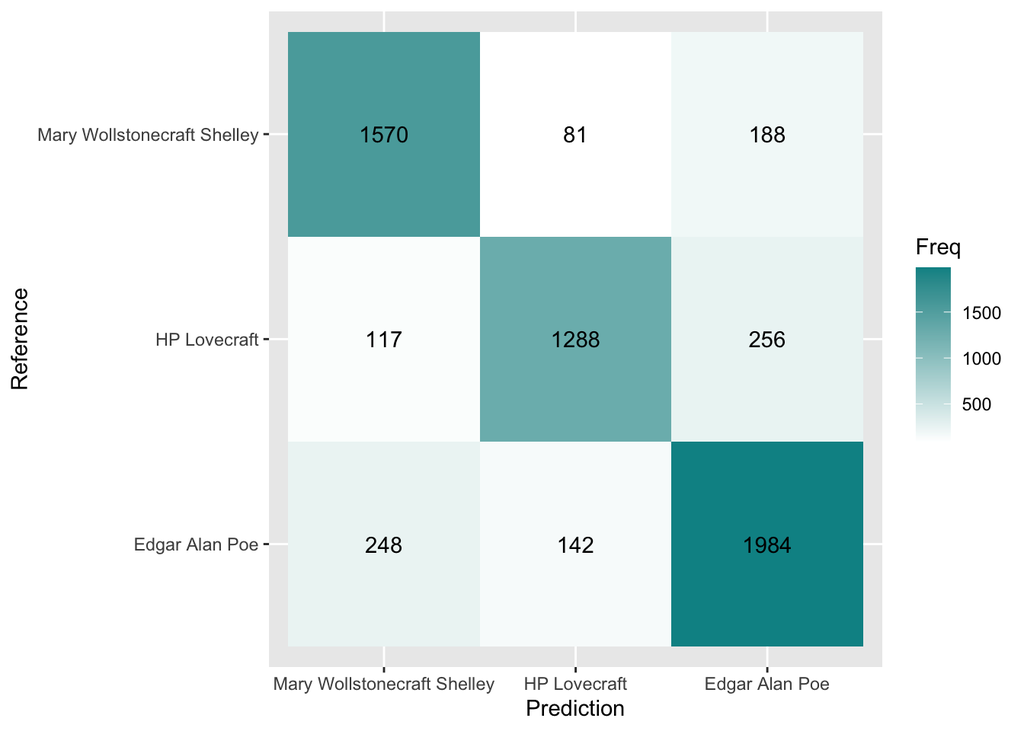

```r
plt <- as.data.frame(cm$table)
plt$Prediction <- factor(plt$Prediction, levels = rev(levels(plt$Prediction)))
print(ggplot(plt, aes(Prediction, Reference, fill = Freq)) +
        geom_tile() +
        geom_text(aes(label = Freq)) +
        scale_fill_gradient(low = "white", high = "#009194") +
        labs(x = "Prediction", y = "Reference") +
        scale_x_discrete(labels = c("Mary Wollstonecraft Shelley", "HP Lovecraft", "Edgar Alan Poe")) +
        scale_y_discrete(labels = c("Edgar Alan Poe", "HP Lovecraft", "Mary Wollstonecraft Shelley")))
```

## Conclusions We implemented a *Naive Bayes classifier*. We used *Bayes’ Theorem* for this task. An interesting thing about our classifier is that we assume that every word in a sentence is independent of the other ones. This means that we’re no longer looking at entire sentences, but rather at individual words. That’s why this classifier is called *naive*.

**Fit:**  
In this method, we processed the training data to form bags of words for each label. We also tried to lemmatize words for faster performance of the classifier.

library(stemwords)  
In *fit()*:  
for (i in 1:nrow(tidy_text)) {  
tidy_text[i, 4] <- lemmatize_words(c(tidy_text[i, 4]))  
}

In *predict():*  
splitted_message <- lemmatize_words(splitted_message)

But the accuracy of the classifier decreased due to the characteristics of the provided data. Thus, we decided not to implement it.

**Predict:**  
In this method, we count the probabilities for each label. We processed the message to look for each word appropriately. In calculations, we discard the divisor while counting probabilities, since it is the same for all the labels. This tactic makes calculations easier and faster. We also used *Laplace smoothing* to avoid nullified probabilities.

**Score:**  
To test our predictions, for every author we calculated recall and precision of predicting(using the r libraries). Using that calculated F1 and got approximately 82% with slight difference for every author.Also we visualized all of the results of our predictions.

**Pros:**  
This algorithm works very fast and can easily predict the class of a test dataset. It can be used for both Binary and Multi-class Classifications. It effectively works in Multi-class predictions.

**Cons:**  
It assumes that all the features are independent, but there few real-life sets of independent features. Thus, it has a quiet limited application.